# Informe_H2_G11

CC5205 - Minería de Datos  
Prof. Felipe Bravo y Hernán Sarmiento

## Hito 2 - Equipo 11

Vicente Guzmán - Ignacio Muñoz - Nicolás González - Javier Atenas - José Arriagada

## Introducción

Steam es la plataforma líder de distribución digital de videojuegos en PC, y este mercado cada vez tiene más consumidores y va ganando terreno por sobre otras formas de entretención. Esto lo demuestra su co-fundador Gabe Newell, el cual con su plataforma es uno de los 1000 hombres más ricos del mundo. Siendo este un mercado en constante cambio con millones de usuarios, vale la pena investigar sobre su contenido, junto a sus ascensos y caídas. Estudiar este dataset podría ayudar a entender las preferencias en el mercado de los videojuegos, cuáles son los más vendidos y cuáles tienen las mejores valoraciones, entre otros estudios.

## Exploración de Datos

Este dataset posee datos de más de 27.000 juegos y algunos pocos softwares estrenados hasta el 2019 en formato CSV. Tiene datos como el nombre, la descripción, la categoría, el género, los logros de cada juego, la fecha de lanzamiento, el desarrollador, el *publisher*, la edad requerida para jugar el juego, la cantidad de gente que posee el juego, el precio, el promedio del tiempo de juego de los usuarios y la puntuación positivas y negativa de los usuarios.

Por como está definido este dataset, la columna "género", al ser de tipo string, cualquier dato que se encuentre es un tipo diferente, a menos que sea exactamente igual a otro. (Ej: "action" es un género diferente a "action;Indie", a pesar de que a nuestro entendimiento, si son del mismo género). Por lo que si se quisiera revisar todos los juegos que sean del género "action", saldrían solamente aquellos juegos que tuviesen como único género "action".

Esto ocurre con varias columnas, por lo que a futuro, se tendrá que modificar o encontrar una forma, para lograr encontrar de manera efectiva varios datos específicos que quisiéramos ver.

Para entender de mejor manera cómo están distribuidos los datos del dataset, se deja el código fuente de la fase exploratoria en la sección de 'Código Fuente'

## Preguntas y Problemas

Usaremos un árbol de regresión lineal que nos ayuda a predecir el precio que tiene un juego en la tienda. para entrenar el modelo usamos el 80% de los datos para entrenar y el 20% restante para testear que tan bueno es el modelo prediciendo.

Para el hito anterior se postularon las siguientes preguntas e hipótesis, que surgieron al hacer la fase exploratoria de los datos:

- ¿Cuáles son los géneros que generan más ingresos?
- ¿Qué géneros tienen un mejor porcentaje de reviews positivas?
- ¿Existe una relación entre el tiempo promedio de juego y sus reviews?  
  Hipótesis: Hay una relación directa entre las reviews de un juego y tiempo de juego, ya que si un jugador no disfruta un juego y le escribe una mala review, tampoco querrá jugarlo, por lo tanto los juegos con altos tiempos de juego tendrán mejores reviews.
- ¿Qué relación hay entre el precio de un juego y su tiempo de juego promedio?  
  Hipótesis: Hay una relación directa entre el precio de un juego y tiempo de juego, ya que los usuarios "harán valer" el dinero invertido, haciendo que jueguen un juego caro mucho más que uno gratis, para sentir que valió la pena.
- ¿Los juegos con más logros tienen más tiempo de juego que los juegos con menos logros?
- ¿Los *publishers* influyen en la cantidad de ventas de un juego?  
  Hipótesis: Si, pues los *publishers* más conocidos harán que el juego se destaque más en el mercado, pues da el sello de garantía de que ellos lo aprobaron, y si la gente confía en ellos, confiarán en este nuevo juego. Mientras que los *indies* tienen menos base de publicidad.

Posterior a la corrección del primer hito, se observaron errores en el enfoque y preguntas realizadas. Esto se logró corregir, mejorando el primer análisis. De la fase exploratoria se pudo observar que las preguntas que se plantean pueden ser resueltas con los datos sin tener que realizar ningún procedimiento muy complejo y no se halló otros dataset que pudieran aportar mayor valor a la investigación. A continuación se enumeran las nuevas preguntas planteadas.

- ¿Sería posible predecir el precio de un nuevo juego de la tienda si solo tengo sus características?
- ¿Existen grupos importantes de juegos que se comporten de manera similar en cuanto a precio de acuerdo a características del juego (promedio tiempo jugado, valoración) o en cuanto al género o tags que posee? ¿Hay alguna relación entre estas?
- ¿Hay características específicas de los juegos que permitan tener mejor o peor valoración del público?
- ¿Sería posible conocer la valoración (aproximada) de un nuevo juego que entra al mercado considerando sus características?

## Propuesta Experimental

- Para examinar mejor los datos necesarios, se extraerán las columnas necesarias para analizar cada pregunta y así bajar la dimensionalidad.
- Dado que las preguntas 1,3 y 4 son de carácter predictivo, el procedimiento se centrará en la clasificación, donde se propone utilizar el dataset que se posee, modificarlo, obtener un modelo que permita obtener la valoración de un juego y así estimar valoración, precio u otros a partir de un conjunto de otras características.
- Para la pregunta 2, se aplicarán técnicas de clustering para encontrar si es que las características del dataset son suficientes para encontrar grupos de juegos similares a otros en características.
- Se probarán múltiples valores en el número de clúster elegidos así como distintos enfoques de clustering.
- Para esto se necesita dejar solo las columnas que contengan valores numéricos, tales como "english", "required_age", "achievements", "positive_ratings", "negative_ratings", "average_playtime", "median_playtime" y "price".
- Se experimentará con distintos subconjuntos de atributos al momento de hacer clustering y así evaluar si los datos se agrupan de manera distinta cuando se consideran características diferentes.

### Experimento Preliminar

Se procede a realizar un experimento preliminar para la pregunta "¿Sería posible predecir el precio de un nuevo juego de la tienda si solo tengo sus características?". Para ver en profundidad el código fuente, se puede revisar la sección de 'Código Fuente'.

- Lo primero es hacer una tabla con las columnas numéricas relevantes para entrenar un modelo que ayude a responder la pregunta.
- Se hace un árbol de regresión lineal.
- Se utiliza el árbol para ayudar a predecir el precio que tiene un juego en la tienda. Para entrenar el modelo se usa el 80% de los datos y el 20% restante se usa para testear qué tan bueno es el modelo.
- Al correr varias veces el código del árbol de regresión lineal obtenemos un Mean Squared Error (MSE) o error cuadrático medio de aproximadamente 131, lo que se traduce a 11 dólares aproximadamente de error. Y considerando que el precio de los juegos varia entre 0 y 400 dólares podemos notar que el modelo tiene un buen ajuste y que las predicciones están en general cercanas a los valores reales.
- Como resultado preliminar, creamos un juego con datos ficticios en todos los atributos pero sin precio, y el modelo supone que su precio será de 50 dólares, pero contando con el error obtenido, se puede afirmar que este valor podría oscilar entre 39 y 61 dólares.

## Contribuciones de cada miembro del equipo

Vicente Guzmán estuvo a cargo de la redacción del informe y de la creación del Jupyter Notebook donde se realizó el hito.

Ignacio Muñoz trabajó en el desarrollo del experimento preliminar, desarrollando el código y los pasos a seguir.

Nicolás González Trabajó en mejorar fallos del hito 1 y en la propuesta experimental general de las preguntas.

Javier Atenas trabajó en la presentación, en la reformulación de las preguntas y en la propuesta experimental de la pregunta 1.

José Arriagada trabajó traspasando el código del hito 1 a python y en la propuesta experimental.

## Código Fuente

### Exploración de datos

Se detalla el código utilizado para la exploración de datos.

Código para acceder al dataset local y definirlo como X, mostrando los primeros elementos.

```python
import pandas as pd
import os

# Cambiar el directorio de trabajo a db
wd = os.path.abspath(os.path.join(os.getcwd(), os.pardir, "db"))
os.chdir(wd)

steam = pd.read_csv("steam.csv")
```

Cantidad de juegos que hay en la base de datos

```python
print(steam.name.nunique())
```

```
27033
```

Cantidad de desarrolladores que hay en la base de datos

```python
print(steam.developer.nunique())
```

```
17113
```

Cantidad de *publishers* que hay en la base de datos

```python
print(steam.publisher.nunique())
```

```
14354
```

Gráfico con las fechas de lanzamiento de los juegos

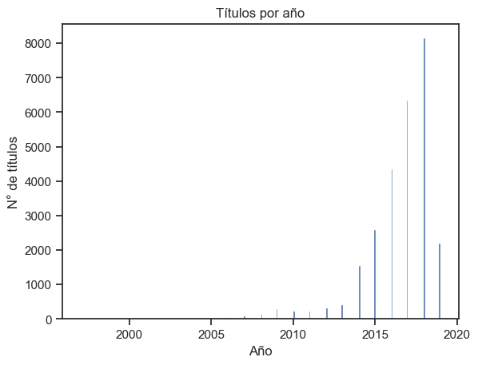

```python
steam['release_date'] = pd.to_datetime(steam['release_date'])
steam['year'] = steam['release_date'].dt.year.astype(int)
plt.hist(steam['year'], bins='auto')
plt.title("Títulos por año")
plt.xlabel("Año")
plt.ylabel("N° de títulos")
plt.show()
```

Juegos que tienen uno o mas géneros en específico

```python
steam2 = steam[steam['genres'].str.contains('Action')]
steam3 = steam[steam['genres'].str.contains('Strategy') & steam['genres'].str.contains('RPG')]
steam2.head()
steam3.head()
```

|  | appid | name | release_date | english | developer | publisher | platforms | required_age | categories | genres | steamspy_tags | achievements | positive_ratings | negative_ratings | average_playtime | median_playtime | owners | price | year |
| --- | --- | --- | --- | --- | --- | --- | --- | --- | --- | --- | --- | --- | --- | --- | --- | --- | --- | --- | --- |
| 86 | 3170 | King's Bounty: Armored Princess | 2009-11-19 | 1 | Katauri Interactive | 1C Entertainment | windows;mac | 0 | Single-player;Steam Cloud | RPG;Strategy | RPG;Turn-Based Strategy;Strategy | 0 | 482 | 53 | 1422 | 1429 | 200000-500000 | 7.99 | 2009 |
| 215 | 8500 | EVE Online | 2010-12-15 | 1 | CCP | CCP | windows;mac | 0 | Multi-player;Online Multi-Player;MMO;Co-op;Onl... | Action;Free to Play;Massively Multiplayer;RPG;... | Space;Massively Multiplayer;Sci-fi | 0 | 8317 | 2832 | 5123 | 230 | 1000000-2000000 | 0.00 | 2010 |
| 220 | 8880 | Freedom Force | 2009-05-29 | 1 | Irrational Games | 2K | windows | 0 | Single-player;Multi-player | RPG;Strategy | RPG;Strategy;Superhero | 0 | 197 | 150 | 16 | 16 | 200000-500000 | 2.99 | 2009 |
| 221 | 8890 | Freedom Force vs. the Third Reich | 2009-05-29 | 1 | Irrational Games | 2K | windows | 0 | Single-player;Multi-player | RPG;Strategy | RPG;Strategy;Superhero | 0 | 121 | 28 | 23 | 23 | 200000-500000 | 2.99 | 2009 |
| 264 | 10270 | Disciples III: Reincarnation | 2014-02-14 | 1 | Akella | Kalypso Media Digital | windows | 0 | Single-player;Multi-player | RPG;Strategy | RPG;Turn-Based Strategy;Strategy | 0 | 618 | 252 | 889 | 889 | 50000-100000 | 9.99 | 2014 |

Juegos que poseen algún género en especíifics

```python
steam4 = steam[steam['genres'].str.contains('Strategy|Action')]
steam4.head()
```

|  | appid | name | release_date | english | developer | publisher | platforms | required_age | categories | genres | steamspy_tags | achievements | positive_ratings | negative_ratings | average_playtime | median_playtime | owners | price | year |
| --- | --- | --- | --- | --- | --- | --- | --- | --- | --- | --- | --- | --- | --- | --- | --- | --- | --- | --- | --- |
| 0 | 10 | Counter-Strike | 2000-11-01 | 1 | Valve | Valve | windows;mac;linux | 0 | Multi-player;Online Multi-Player;Local Multi-P... | Action | Action;FPS;Multiplayer | 0 | 124534 | 3339 | 17612 | 317 | 10000000-20000000 | 7.19 | 2000 |
| 1 | 20 | Team Fortress Classic | 1999-04-01 | 1 | Valve | Valve | windows;mac;linux | 0 | Multi-player;Online Multi-Player;Local Multi-P... | Action | Action;FPS;Multiplayer | 0 | 3318 | 633 | 277 | 62 | 5000000-10000000 | 3.99 | 1999 |
| 2 | 30 | Day of Defeat | 2003-05-01 | 1 | Valve | Valve | windows;mac;linux | 0 | Multi-player;Valve Anti-Cheat enabled | Action | FPS;World War II;Multiplayer | 0 | 3416 | 398 | 187 | 34 | 5000000-10000000 | 3.99 | 2003 |
| 3 | 40 | Deathmatch Classic | 2001-06-01 | 1 | Valve | Valve | windows;mac;linux | 0 | Multi-player;Online Multi-Player;Local Multi-P... | Action | Action;FPS;Multiplayer | 0 | 1273 | 267 | 258 | 184 | 5000000-10000000 | 3.99 | 2001 |
| 4 | 50 | Half-Life: Opposing Force | 1999-11-01 | 1 | Gearbox Software | Valve | windows;mac;linux | 0 | Single-player;Multi-player;Valve Anti-Cheat en... | Action | FPS;Action;Sci-fi | 0 | 5250 | 288 | 624 | 415 | 5000000-10000000 | 3.99 | 1999 |

Juegos que no poseen alguno o mas géneros en específico

```python
steam5 = steam[~steam['genres'].str.contains('Action')]
steam6 = steam[~steam['genres'].str.contains('Strategy|Action')]
steam5.head()
steam6.head()
```

|  | appid | name | release_date | english | developer | publisher | platforms | required_age | categories | genres | steamspy_tags | achievements | positive_ratings | negative_ratings | average_playtime | median_playtime | owners | price | year |
| --- | --- | --- | --- | --- | --- | --- | --- | --- | --- | --- | --- | --- | --- | --- | --- | --- | --- | --- | --- |
| 26 | 1002 | Rag Doll Kung Fu | 2005-10-12 | 1 | Mark Healey | Mark Healey | windows | 0 | Single-player;Multi-player | Indie | Indie;Fighting;Multiplayer | 0 | 40 | 17 | 0 | 0 | 20000-50000 | 5.99 | 2005 |
| 33 | 1530 | Multiwinia | 2008-09-19 | 1 | Introversion Software | Introversion Software | windows;mac | 0 | Single-player;Multi-player;Steam Achievements | Indie | Indie;RTS;Strategy | 12 | 368 | 75 | 121 | 224 | 500000-1000000 | 7.19 | 2008 |
| 40 | 1700 | Arx Fatalis | 2007-04-03 | 1 | Arkane Studios | Arkane Studios | windows | 0 | Single-player | RPG | RPG;First-Person;Classic | 0 | 671 | 106 | 11 | 21 | 100000-200000 | 2.99 | 2007 |
| 41 | 1840 | Source Filmmaker | 2012-07-10 | 1 | Valve | Valve | windows | 0 | Steam Workshop | Animation & Modeling;Video Production | Animation & Modeling;Video Production;Free to ... | 0 | 15083 | 1111 | 239 | 77 | 1000000-2000000 | 0.00 | 2012 |
| 43 | 1930 | Two Worlds Epic Edition | 2009-04-30 | 1 | Reality Pump Studios | Topware Interactive | windows;mac;linux | 0 | Single-player;Multi-player;Online Multi-Player... | RPG | RPG;Open World;Fantasy | 0 | 2656 | 1055 | 484 | 422 | 1000000-2000000 | 6.99 | 2009 |

### Experimento preliminar

Se detalla el código utilizado para el experimento preliminar que intenta contestar la pregunta 1 estipulada para este hito.

Tabla con las columnas numéricas relevantes.

```python
columnas_numericas = ("english", "required_age", "achievements", "positive_ratings", "negative_ratings", "average_playtime", "median_playtime", "price")
X = steam[list(columnas_numericas)]
X.head()
```

|  | english | required_age | achievements | positive_ratings | negative_ratings | average_playtime | median_playtime | price |
| --- | --- | --- | --- | --- | --- | --- | --- | --- |
| 0 | 1 | 0 | 0 | 124534 | 3339 | 17612 | 317 | 7.19 |
| 1 | 1 | 0 | 0 | 3318 | 633 | 277 | 62 | 3.99 |
| 2 | 1 | 0 | 0 | 3416 | 398 | 187 | 34 | 3.99 |
| 3 | 1 | 0 | 0 | 1273 | 267 | 258 | 184 | 3.99 |
| 4 | 1 | 0 | 0 | 5250 | 288 | 624 | 415 | 3.99 |

Árbol de regresión lineal con el 80% de los datos para entrenar y el 20% restante para testear.

```python
from sklearn.tree import DecisionTreeRegressor
from sklearn.model_selection import train_test_split
from sklearn.metrics import mean_squared_error

clf = DecisionTreeRegressor()
y = X.price
Xwp = X.copy()
Xwp = Xwp.drop("price", axis=1)
clf.fit(Xwp, y)
X_train, X_test, y_train, y_test = train_test_split(Xwp, y, test_size=0.2, random_state=42)

regressor = DecisionTreeRegressor()
regressor.fit(X_train, y_train)

y_pred = regressor.predict(X_test)
mse = mean_squared_error(y_test, y_pred)
print("Mean Squared Error (MSE):", mse)
```

```
Mean Squared Error (MSE): 131.67187134852313
```

Juego ficticio con valores ficticios.

```python
import warnings
warnings.filterwarnings("ignore")

# Valores de ejemplo para los otros atributos
english = 1
required_age = 18
achievements = 50
positive_ratings = 1000
negative_ratings = 200
average_playtime = 120
median_playtime = 90

# Preparar los valores de los atributos para la predicción
input_data = [[english, required_age, achievements, positive_ratings, negative_ratings, average_playtime, median_playtime]]

# Realizar la predicción
predicted_price = regressor.predict(input_data)

# Imprimir el valor predicho
print("Predicted Price:", predicted_price)
```

```
Predicted Price: [49.99]
```